# Dublin Data Science Workshop on Time Series Analysis

Mick Cooney mickcooney@gmail.com

Monday, 21 January 2019

# 1 Introduction

Time series occur in most fields of study that produce quantitative data. Whenever quantities are measured over time, those measurements form a time-series, or more formally, a discrete-time stochastic process.

## 1.1 Workshop Materials

All materials for this workshop is available in my standard GitHub repo:

https://github.com/kaybenleroll/data_workshops

The content of this workshop is partly based on the book “Introductory Time Series with R” by Paul Cowpertwait and Andrew Metcalfe. The data from this book is available from the website:

http://www.maths.adelaide.edu.au/emac2009/

[figure not shown]

For further resources, anyone with an interest in this topic should take a look at the book “Forecasting: Principles and Practice” by Rob J Hyndman and George Athanasopoulos

[figure not shown]

While available as in dead-tree form, the full text is available online:

https://otexts.com/fpp2/

One final recommendation is the book “The Analysis of Time Series” by Christopher Chatfield. This is a principles and theory-based book on the underlying statistical concepts around time-series analysis and does not contain much in the way of code, but is still highly recommended.

[figure not shown]

### 1.1.1 R Packages

In this workshop we focus on the use of ‘tidy’-style tools in the analysis of time-series. In particular we look at packages such as `tidyquant` that enable and simplify this approach to time-series analysis.

## 1.2 Basic Concepts

A famous example of a time-series is count of airline passengers in the US, as shown in the figure below. This is a simple univariate time-series, with measurements taken on a monthly basis over a number of years, each datum consisting of a single number - the number of passengers travelling via a commercial flight that month.

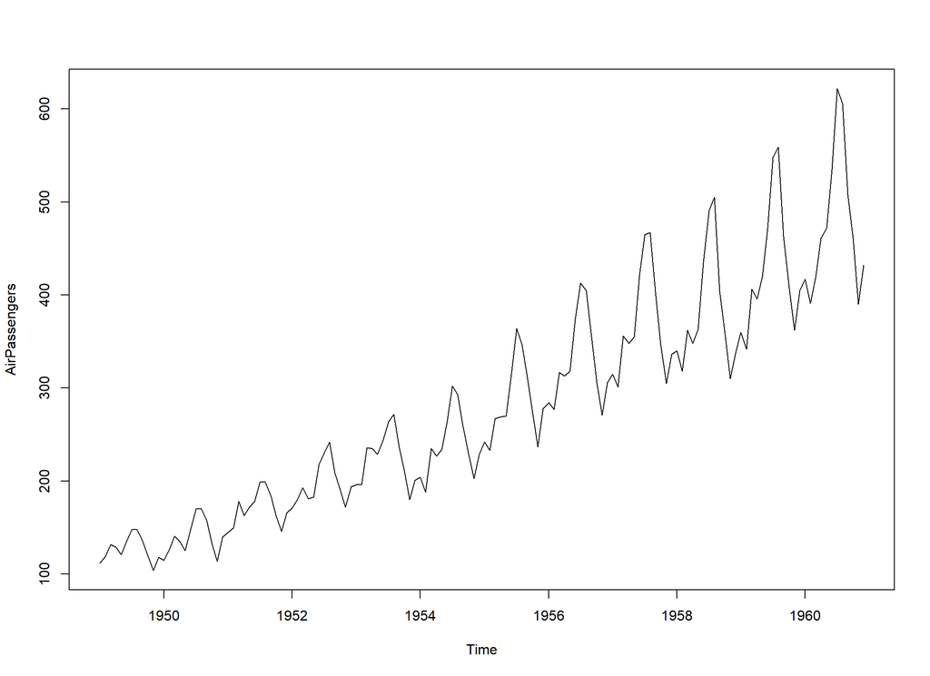

```r
plot(AirPassengers)
```

Before we begin analysing such data, we first need to create a mathematical framework to work in. Fortunately, we do not need anything too complicated, and for a finite time-series of length $N$, we model the time series as a sequence of $N$ random variables, $X_i$, with $i = 1, 2, ..., N$.

Note that each individual $X_i$ is a wholly separate random variable: we only ever have a single measurement from each random variable. In many cases we simplify this, but it is important to understand and appreciate that such simplifications are just that. Time series are difficult to analyse.

Before we get to any of that though, and before we try to build any kind of models for the data, we always start with visualising the data. Often, a simple plot of the data helps use pick out aspects to analyse and incorporate into the models. For time series, one of the first things to do is the *time plot*, a simple plot of the data over time.

For the passenger data, a few aspects stand out that are very common in time series. It is apparent that the numbers increase over time, and this systematic change in the data is called the *trend*. Often, approximating the trend as a linear function of time is adequate for many data sets.

A repeating pattern in the data that occurs over the period of the data (in this case, each year), is called the *seasonal variation*, though a more general concept of ‘season’ is implied — it often will not coincide with the seasons of the calendar.

A slightly more generalised concept from the seasonality is that of *cycles*, repeating patterns in the data that do not correspond to the natural fixed periods of the model. None of these are apparent in the air passenger data, and accounting for them are beyond the scope of this introductory tutorial.

Finally, another important benefit of visualising the data is that it helps identify possible *outliers* and *erroneous* data.

In many cases, we will also be dealing with time series that have multiple values at all, many or some of the points in time.

Often, these values will be related in some ways, and we will want to analyse those relationships also. In fact, one of the most efficient methods of prediction is to find *leading indicators* for the value or values you wish to predict — you can often use the current values of the leading indicators to make inference on future values of the related quantities.

The fact that this is one of the best methods in time series analysis says a lot about the difficulty of prediction (Yogi Berra, a US baseball player noted for his pithy statements, once said “Prediction is difficult, especially about the future”).

## 1.3 Example Timeseries

In this workshop we will look at a number of different time-series, discussed here.

This data comes in a few different format, and this workshop discusses methods for analysing this data in a common format.

### 1.3.1 Air Passenger Data

As mentioned previously, a canonical time-series is the airline passenger dataset, and this is the first dataset we look at.

```r
AirPassengers %>% print()
```

```
##      Jan Feb Mar Apr May Jun Jul Aug Sep Oct Nov Dec
## 1949 112 118 132 129 121 135 148 148 136 119 104 118
## 1950 115 126 141 135 125 149 170 170 158 133 114 140
## 1951 145 150 178 163 172 178 199 199 184 162 146 166
## 1952 171 180 193 181 183 218 230 242 209 191 172 194
## 1953 196 196 236 235 229 243 264 272 237 211 180 201
## 1954 204 188 235 227 234 264 302 293 259 229 203 229
## 1955 242 233 267 269 270 315 364 347 312 274 237 278
## 1956 284 277 317 313 318 374 413 405 355 306 271 306
## 1957 315 301 356 348 355 422 465 467 404 347 305 336
## 1958 340 318 362 348 363 435 491 505 404 359 310 337
## 1959 360 342 406 396 420 472 548 559 463 407 362 405
## 1960 417 391 419 461 472 535 622 606 508 461 390 432
```

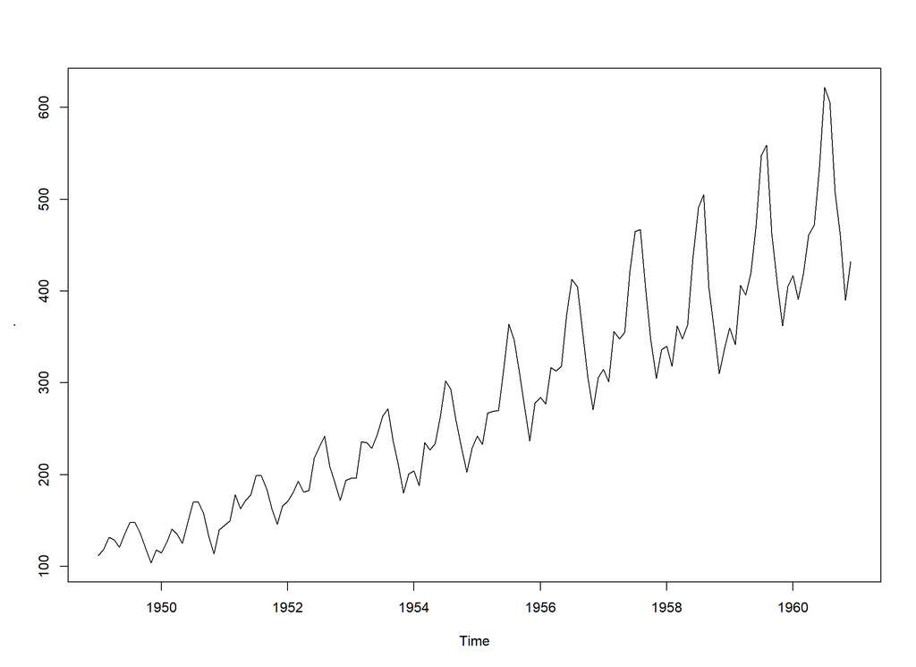

```r
AirPassengers %>% plot()
```

In this workshop we will convert all time series into the tibbles: the package `timetk` allows us to do this.

```r
airpassengers_tbl <- AirPassengers %>% tk_tbl(rename_index = 'month')

airpassengers_tbl %>% print()
```

```
## # A tibble: 144 x 2
##    month         value
##    <S3: yearmon> <dbl>
##  1 Jan 1949        112
##  2 Feb 1949        118
##  3 Mar 1949        132
##  4 Apr 1949        129
##  5 May 1949        121
##  6 Jun 1949        135
##  7 Jul 1949        148
##  8 Aug 1949        148
##  9 Sep 1949        136
## 10 Oct 1949        119
## # ... with 134 more rows
```

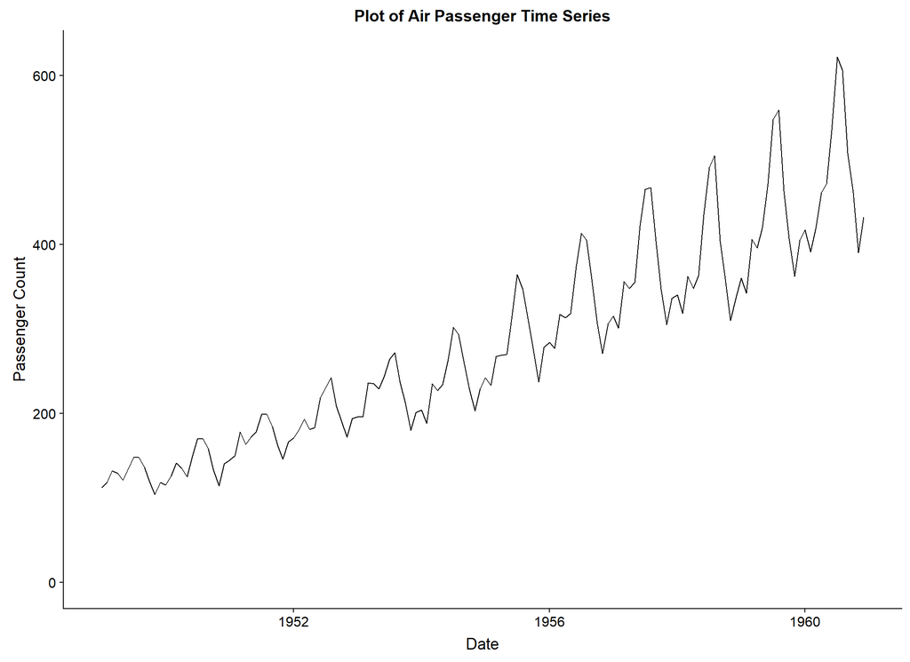

```r
ggplot(airpassengers_tbl) +
    geom_line(aes(x = month, y = value)) +
    xlab('Date') +
    ylab('Passenger Count') +
    expand_limits(y = 0) +
    ggtitle('Plot of Air Passenger Time Series')
```

### 1.3.2 Maine Unemployment Data

Time series are very common in econometrics, and a dataset provided in the text is that of monthly unemployment statistics in Maine from 1996 on. I have included the datafile in this workshop.

```r
maine_ts <- scan('data/Maine.dat', skip = 1) %>%
    ts(start = 1996, frequency = 12)

maine_ts %>% print()
```

```
##      Jan Feb Mar Apr May Jun Jul Aug Sep Oct Nov Dec
## 1996 6.7 6.7 6.4 5.9 5.2 4.8 4.8 4.0 4.2 4.4 5.0 5.0
## 1997 6.4 6.5 6.3 5.9 4.9 4.8 4.5 4.0 4.1 4.3 4.8 5.0
## 1998 6.2 5.7 5.6 4.6 4.0 4.2 4.1 3.6 3.7 4.1 4.3 4.0
## 1999 4.9 5.0 4.6 4.3 3.9 4.0 3.6 3.3 3.1 3.3 3.7 3.7
## 2000 4.4 4.4 4.1 3.5 3.1 3.0 2.8 2.5 2.6 2.8 3.1 3.0
## 2001 3.9 4.2 4.0 4.1 3.5 3.5 3.4 3.1 3.4 3.7 4.0 4.0
## 2002 5.0 4.9 5.0 4.7 4.0 4.2 4.0 3.6 3.7 3.9 4.5 4.6
## 2003 5.6 5.8 5.6 5.5 4.8 4.9 4.8 4.3 4.5 4.6 4.8 4.7
## 2004 5.6 5.6 5.5 4.8 4.2 4.3 4.2 3.8 4.0 4.2 4.6 4.6
## 2005 5.5 5.8 5.5 5.2 4.7 4.6 4.5 4.1 4.4 4.4 4.8 4.6
## 2006 5.3 5.6 4.9 4.6 4.2 4.4 4.4 3.9
```

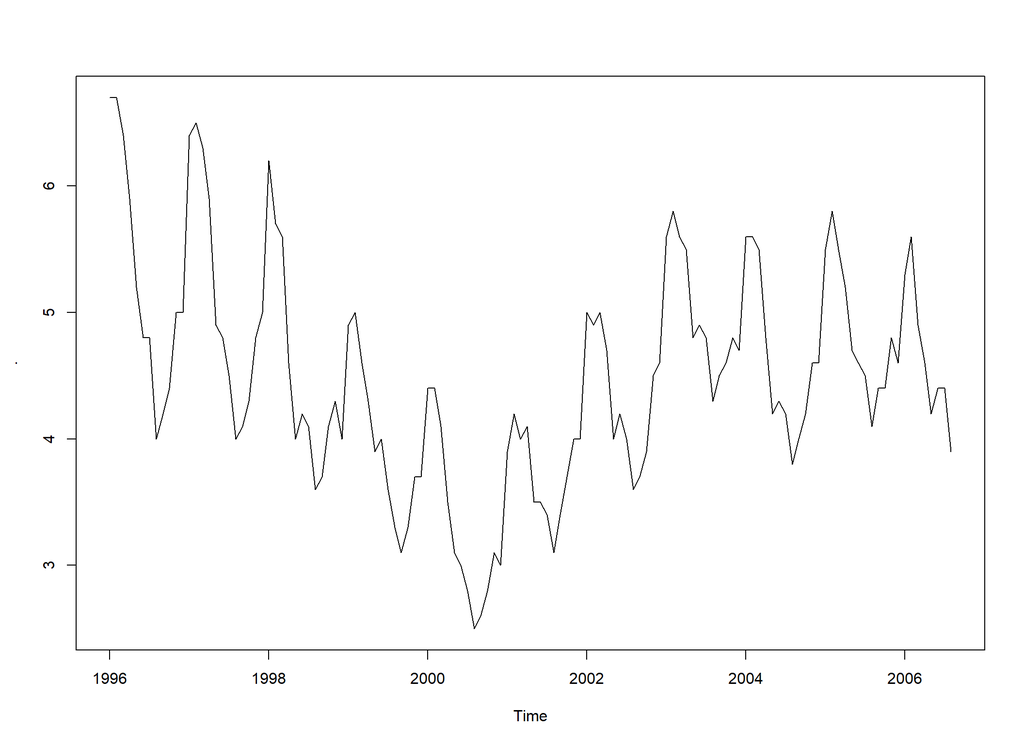

```r
maine_ts %>% plot()
```

As before, we convert this data into a tibble and recreate the plot using `ggplot2`.

```r
maine_tbl <- maine_ts %>% tk_tbl(rename_index = 'month')

maine_tbl %>% print()
```

```
## # A tibble: 128 x 2
##    month         value
##    <S3: yearmon> <dbl>
##  1 Jan 1996        6.7
##  2 Feb 1996        6.7
##  3 Mar 1996        6.4
##  4 Apr 1996        5.9
##  5 May 1996        5.2
##  6 Jun 1996        4.8
##  7 Jul 1996        4.8
##  8 Aug 1996        4
##  9 Sep 1996        4.2
## 10 Oct 1996        4.4
## # ... with 118 more rows
```

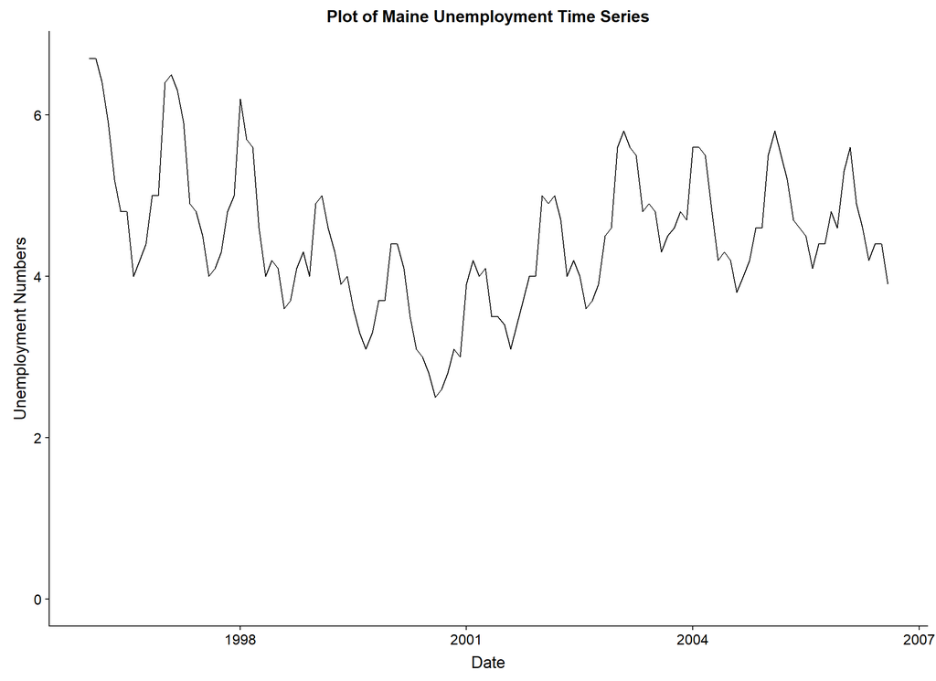

```r
ggplot(maine_tbl) +
    geom_line(aes(x = month, y = value)) +
    xlab('Date') +
    ylab('Unemployment Numbers') +
    expand_limits(y = 0) +
    ggtitle('Plot of Maine Unemployment Time Series')
```

### 1.3.3 Australian Consumption Statistics (CBE)

Governments produce regular data on consumption numbers for their economy.

One such dataset is contained in the file `cbe.dat`, produced by the Australian Census Bureau containing data of chocolate, beer and energy production on a monthly basis.

```r
cbe_raw_tbl <- read_tsv('data/cbe.dat')

cbe_raw_tbl %>% glimpse()
```

```
## Observations: 396
## Variables: 3
## $ choc <dbl> 1451, 2037, 2477, 2785, 2994, 2681, 3098, 2708, 2517, 2445, 20...
## $ beer <dbl> 96.3, 84.4, 91.2, 81.9, 80.5, 70.4, 74.8, 75.9, 86.3, 98.7, 10...
## $ elec <dbl> 1497, 1463, 1648, 1595, 1777, 1824, 1994, 1835, 1787, 1699, 16...
```

Similar to the Maine file, this data does not contain time indices for the data. For the sake of completeness, we use the same approach as before and convert to a tibble, but we will also show how to construct the time index without having to do intermediate conversions.

First we add time indices via `ts` conversions.

```r
cbe_ts <- cbe_raw_tbl %>%
    as.matrix() %>%
    ts(start = 1958, frequency = 12)

cbe_ts %>% head(10)
```

```
##          choc beer elec
## Jan 1958 1451 96.3 1497
## Feb 1958 2037 84.4 1463
## Mar 1958 2477 91.2 1648
## Apr 1958 2785 81.9 1595
## May 1958 2994 80.5 1777
## Jun 1958 2681 70.4 1824
## Jul 1958 3098 74.8 1994
## Aug 1958 2708 75.9 1835
## Sep 1958 2517 86.3 1787
## Oct 1958 2445 98.7 1699
```

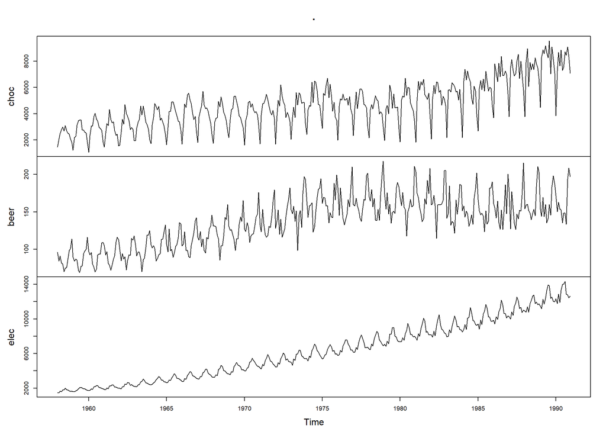

```r
cbe_ts %>% plot()
```

An alternative approach is to add the time index directly.

```r
n_data <- cbe_raw_tbl %>% nrow()

cbe_tbl <- cbe_raw_tbl %>%
    add_column(month = (1958 + (0:(n_data-1)/12)) %>% yearmon, .before = 1)


cbe_tbl %>% glimpse()
```

```
## Observations: 396
## Variables: 4
## $ month <S3: yearmon> Jan 1958, Feb 1958, Mar 1958, Apr 1958, May 1958, Jun...
## $ choc  <dbl> 1451, 2037, 2477, 2785, 2994, 2681, 3098, 2708, 2517, 2445, 2...
## $ beer  <dbl> 96.3, 84.4, 91.2, 81.9, 80.5, 70.4, 74.8, 75.9, 86.3, 98.7, 1...
## $ elec  <dbl> 1497, 1463, 1648, 1595, 1777, 1824, 1994, 1835, 1787, 1699, 1...
```

```r
cbe_tbl %>% print()
```

```
## # A tibble: 396 x 4
##    month          choc  beer  elec
##    <S3: yearmon> <dbl> <dbl> <dbl>
##  1 Jan 1958       1451  96.3  1497
##  2 Feb 1958       2037  84.4  1463
##  3 Mar 1958       2477  91.2  1648
##  4 Apr 1958       2785  81.9  1595
##  5 May 1958       2994  80.5  1777
##  6 Jun 1958       2681  70.4  1824
##  7 Jul 1958       3098  74.8  1994
##  8 Aug 1958       2708  75.9  1835
##  9 Sep 1958       2517  86.3  1787
## 10 Oct 1958       2445  98.7  1699
## # ... with 386 more rows
```

Having constructed the tibble, we now construct these time series plots using `ggplot2`.

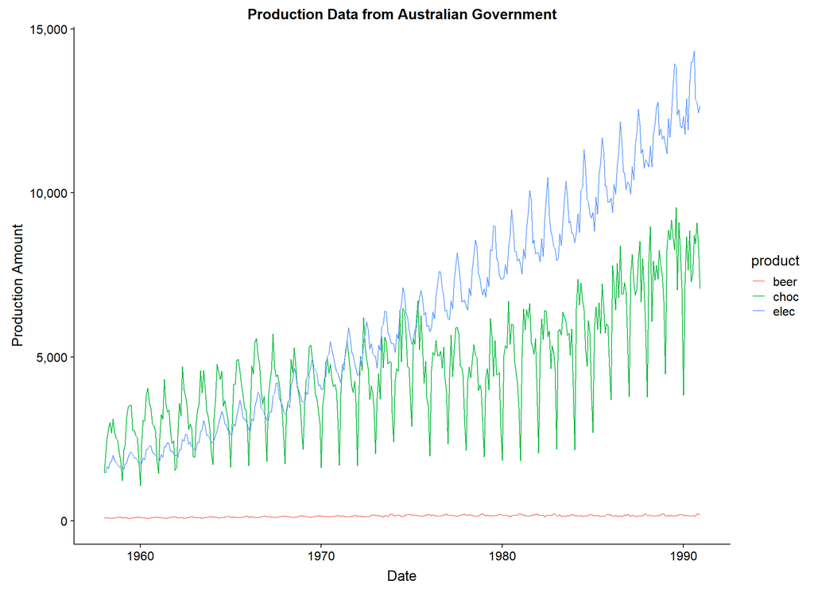

```r
plot_tbl <- cbe_tbl %>%
    gather('product', 'value', -month)

ggplot(plot_tbl) +
    geom_line(aes(x = month, y = value, colour = product)) +
    expand_limits(y = 0) +
    xlab("Date") +
    ylab("Production Amount") +
    scale_y_continuous(labels = comma) +
    ggtitle('Production Data from Australian Government')
```

Due to the different scales, it might be more useful to use a faceted plot for each product:

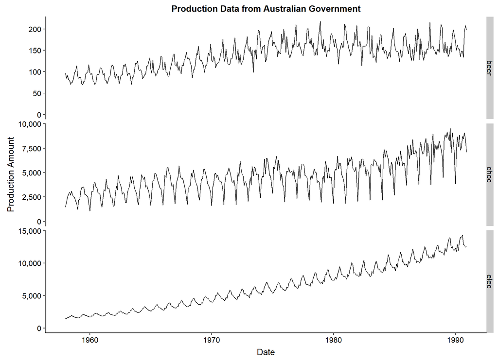

```r
plot_tbl <- cbe_tbl %>%
    gather('product', 'value', -month)

ggplot(plot_tbl) +
    geom_line(aes(x = month, y = value)) +
    facet_grid(rows = vars(product), scales = 'free_y') +
    expand_limits(y = 0) +
    xlab("Date") +
    ylab("Production Amount") +
    scale_y_continuous(labels = comma) +
    ggtitle('Production Data from Australian Government')
```

### 1.3.4 Australian Building Activity

Another set of data produced by the Australian Census Bureau is the Building Activity Publication listing the value of building work done in each quarter. This data contains the total dwellings approved for construction per month, averaged over the past three months, and the value of work done over the past three months.

This data is quarterly from 1996, and we construct the data as before.

```r
approvactiv_raw_tbl <- read_tsv('data/ApprovActiv.dat')

approvactiv_raw_tbl %>% glimpse()
```

```
## Observations: 43
## Variables: 2
## $ Approvals <dbl> 9988.0, 10320.3, 10682.3, 11086.7, 11604.0, 11861.0, 1241...
## $ Activity  <dbl> 5747.0, 6388.8, 6715.6, 7048.2, 6600.4, 6919.6, 7255.6, 7...
```

```r
approvactiv_ts <- approvactiv_raw_tbl %>%
    as.matrix() %>%
    ts(start = 1996, frequency = 4)

approvactiv_ts %>% head(10)
```

```
##         Approvals Activity
## 1996 Q1    9988.0   5747.0
## 1996 Q2   10320.3   6388.8
## 1996 Q3   10682.3   6715.6
## 1996 Q4   11086.7   7048.2
## 1997 Q1   11604.0   6600.4
## 1997 Q2   11861.0   6919.6
## 1997 Q3   12418.7   7255.6
## 1997 Q4   12887.0   7211.5
## 1998 Q1   13212.3   7724.6
## 1998 Q2   13486.0   7952.1
```

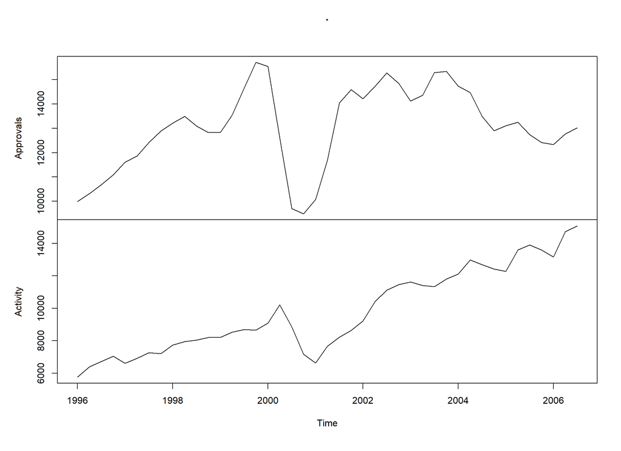

```r
approvactiv_ts %>% plot()
```

```r
approvactiv_tbl <- approvactiv_ts %>%
    tk_tbl(rename_index = 'quarter')

approvactiv_tbl %>% glimpse()
```

```
## Observations: 43
## Variables: 3
## $ quarter   <S3: yearqtr> 1996 Q1, 1996 Q2, 1996 Q3, 1996 Q4, 1997 Q1, 1997...
## $ Approvals <dbl> 9988.0, 10320.3, 10682.3, 11086.7, 11604.0, 11861.0, 1241...
## $ Activity  <dbl> 5747.0, 6388.8, 6715.6, 7048.2, 6600.4, 6919.6, 7255.6, 7...
```

```r
approvactiv_tbl %>% print()
```

```
## # A tibble: 43 x 3
##    quarter       Approvals Activity
##    <S3: yearqtr>     <dbl>    <dbl>
##  1 1996 Q1           9988     5747
##  2 1996 Q2          10320.    6389.
##  3 1996 Q3          10682.    6716.
##  4 1996 Q4          11087.    7048.
##  5 1997 Q1          11604     6600.
##  6 1997 Q2          11861     6920.
##  7 1997 Q3          12419.    7256.
##  8 1997 Q4          12887     7212.
##  9 1998 Q1          13212.    7725.
## 10 1998 Q2          13486     7952.
## # ... with 33 more rows
```

As before, we can produce time plots in `ggplot2`.

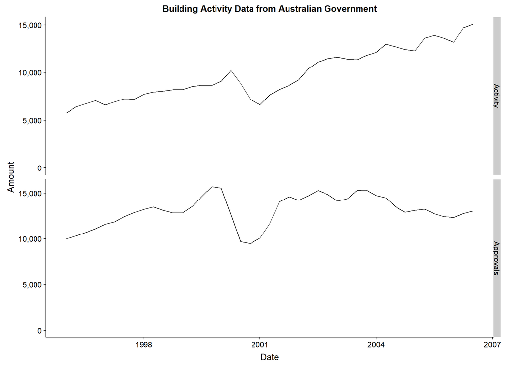

```r
plot_tbl <- approvactiv_tbl %>%
    gather('label', 'value', -quarter)

ggplot(plot_tbl) +
    geom_line(aes(x = quarter, y = value)) +
    facet_grid(rows = vars(label), scales = 'free_y') +
    expand_limits(y = 0) +
    xlab("Date") +
    ylab("Amount") +
    scale_y_continuous(labels = comma) +
    ggtitle('Building Activity Data from Australian Government')
```

### 1.3.5 CRAN Package Downloads Data

An interesting dataset is the daily count of package downloads from CRAN. This data is easy to obtain via use of the package `cranlogs`, which gives us use of the `cran_downloads()` function.

For this workshop, we will look at some of the main packages that comprise the ‘tidyverse’, as well as the total number of downloads from CRAN.

```r
cran_data_file <- 'data/cran_download_data.csv'

if(file.exists(cran_data_file)) {
    cran_data_tbl <- read_csv(cran_data_file)
} else {
    cran_pkgs <- c('dplyr', 'tidyr', 'ggplot2', 'lubridate', 'stringr', 'tibble'
                  ,'broom', 'jsonlite', 'purrr', 'readr', 'tidyquant')


    cran_data_tbl <- retrieve_cran_download_data(cran_pkgs, '2014-01-01', '2018-12-31')

    write_csv(cran_data_tbl, path = cran_data_file)
}


cran_data_tbl %>% glimpse()
```

```
## Observations: 21,912
## Variables: 3
## $ date    <date> 2014-01-01, 2014-01-02, 2014-01-03, 2014-01-04, 2014-01-05...
## $ count   <dbl> 0, 0, 0, 0, 0, 0, 0, 0, 0, 0, 0, 0, 0, 0, 0, 0, 77, 138, 12...
## $ package <chr> "dplyr", "dplyr", "dplyr", "dplyr", "dplyr", "dplyr", "dply...
```

```r
cran_data_tbl %>% print()
```

```
## # A tibble: 21,912 x 3
##    date       count package
##    <date>     <dbl> <chr>
##  1 2014-01-01     0 dplyr
##  2 2014-01-02     0 dplyr
##  3 2014-01-03     0 dplyr
##  4 2014-01-04     0 dplyr
##  5 2014-01-05     0 dplyr
##  6 2014-01-06     0 dplyr
##  7 2014-01-07     0 dplyr
##  8 2014-01-08     0 dplyr
##  9 2014-01-09     0 dplyr
## 10 2014-01-10     0 dplyr
## # ... with 21,902 more rows
```

First we construct a simple line plot of the download counts, facetted by package.

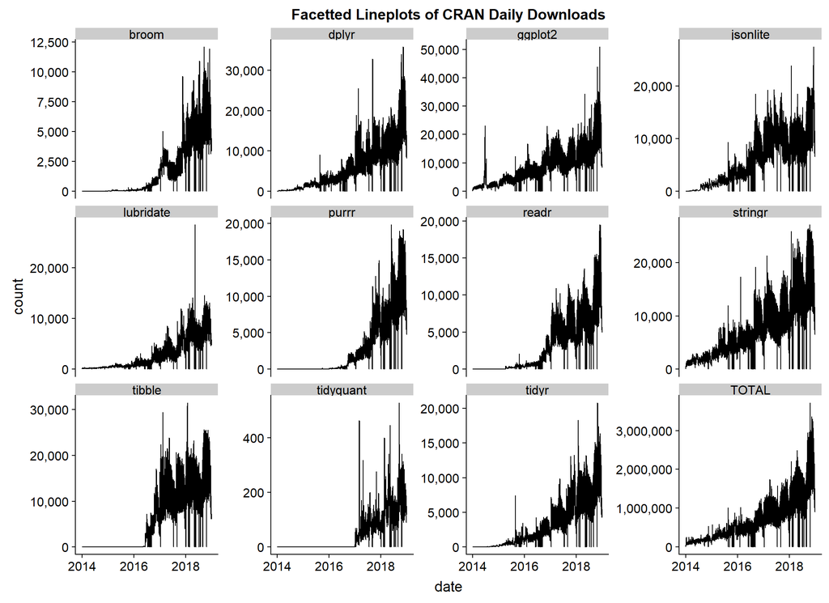

```r
ggplot(cran_data_tbl) +
    geom_line(aes(x = date, y = count)) +
    facet_wrap(vars(package), scales = 'free_y') +
    expand_limits(y = 0) +
    scale_y_continuous(labels = comma) +
    ggtitle('Facetted Lineplots of CRAN Daily Downloads')
```

Not all packages have download data as some packages were created after the start of our observation period. This manifests as zero counts for that package. We discuss these issues later on in the workshop.

## 1.4 Combining Time Series

Useful insights are often gained from combining different datasets together.

Looking at our datasets, one possible interesting relationship is that between energy production and airline passengers – it is reasonable to expect that both of these quantities will be related as they are related to the overall health and size of the economy.

A major benefit of using tidy tools for time series is to make such data manipulation and arrangement simple: combining datasets is simply a matter of using the two-table joins.

To illustrate, we combine the Air Passenger data with the Australian economic data, using the following code. Note that we rename the air passenger data at the end to make it more meaningful and useful.

```r
ap_econ_combined_tbl <- airpassengers_tbl %>%
    left_join(cbe_tbl, by = 'month') %>%
    filter(complete.cases(.)) %>%
    rename(air = value)


ap_econ_combined_tbl %>% glimpse()
```

```
## Observations: 36
## Variables: 5
## $ month <S3: yearmon> Jan 1958, Feb 1958, Mar 1958, Apr 1958, May 1958, Jun...
## $ air   <dbl> 340, 318, 362, 348, 363, 435, 491, 505, 404, 359, 310, 337, 3...
## $ choc  <dbl> 1451, 2037, 2477, 2785, 2994, 2681, 3098, 2708, 2517, 2445, 2...
## $ beer  <dbl> 96.3, 84.4, 91.2, 81.9, 80.5, 70.4, 74.8, 75.9, 86.3, 98.7, 1...
## $ elec  <dbl> 1497, 1463, 1648, 1595, 1777, 1824, 1994, 1835, 1787, 1699, 1...
```

```r
ap_econ_combined_tbl %>% print()
```

```
## # A tibble: 36 x 5
##    month           air  choc  beer  elec
##    <S3: yearmon> <dbl> <dbl> <dbl> <dbl>
##  1 Jan 1958        340  1451  96.3  1497
##  2 Feb 1958        318  2037  84.4  1463
##  3 Mar 1958        362  2477  91.2  1648
##  4 Apr 1958        348  2785  81.9  1595
##  5 May 1958        363  2994  80.5  1777
##  6 Jun 1958        435  2681  70.4  1824
##  7 Jul 1958        491  3098  74.8  1994
##  8 Aug 1958        505  2708  75.9  1835
##  9 Sep 1958        404  2517  86.3  1787
## 10 Oct 1958        359  2445  98.7  1699
## # ... with 26 more rows
```

We return to this dataset later in the workshop.

# 2 Manipulation of Time Series Data

Much like all data, it is rate to get time-series exactly in the format we want for analysis. For various reasons, we may want to analyse transformations or aggregations of this data.

Much like feature engineering and variable selection, this process can be more art than science - there are no hard and fast rules, merely principles and rules-of-thumb.

The last few years in particular have seen the development of a number of tools to aid us with the analysis of time series along ‘tidy’ principles. In particular, we will focus on the use of `tidyquant` - a package aimed at analysing financial data, but which is also very useful for time series.

## 2.1 Aggregating Data

From a conceptual point of view, aggregating time series is the most straightforward - we group the data by longer periods of time and aggregate each individual ‘bucket’ of data as desired or required.

### 2.1.1 Single Statistics

As an example of this, suppose we wish to look at the air passenger data as an annual sum for each year. Our data is monthly, so we need to aggregate this data into annual numbers.

```r
ap_yearly_dplyr_tbl <- airpassengers_tbl %>%
    group_by(year = month %>% format('%Y') %>% as.numeric()) %>%
    summarise(ann_total = sum(value))


ap_yearly_dplyr_tbl %>% glimpse()
```

```
## Observations: 12
## Variables: 2
## $ year      <dbl> 1949, 1950, 1951, 1952, 1953, 1954, 1955, 1956, 1957, 195...
## $ ann_total <dbl> 1520, 1676, 2042, 2364, 2700, 2867, 3408, 3939, 4421, 457...
```

```r
ap_yearly_dplyr_tbl %>% print()
```

```
## # A tibble: 12 x 2
##     year ann_total
##    <dbl>     <dbl>
##  1  1949      1520
##  2  1950      1676
##  3  1951      2042
##  4  1952      2364
##  5  1953      2700
##  6  1954      2867
##  7  1955      3408
##  8  1956      3939
##  9  1957      4421
## 10  1958      4572
## 11  1959      5140
## 12  1960      5714
```

The above transformation was straightforward using existing `dplyr` functionality, but we can also use routines provided for by `tidyquant` and its function `tq_transmute`:

```r
ap_yearly_tidyquant_tbl <- airpassengers_tbl %>%
    tq_transmute(
        select     = value
       ,mutate_fun = apply.yearly
       ,FUN        = sum
       ,na.rm      = TRUE
       ,col_rename = 'ann_total'
    ) %>%
    mutate(year = month %>% format('%Y') %>% as.numeric())


ap_yearly_tidyquant_tbl %>% glimpse()
```

```
## Observations: 12
## Variables: 3
## $ month     <S3: yearmon> Dec 1949, Dec 1950, Dec 1951, Dec 1952, Dec 1953,...
## $ ann_total <dbl> 1520, 1676, 2042, 2364, 2700, 2867, 3408, 3939, 4421, 457...
## $ year      <dbl> 1949, 1950, 1951, 1952, 1953, 1954, 1955, 1956, 1957, 195...
```

```r
ap_yearly_tidyquant_tbl %>% print()
```

```
## # A tibble: 12 x 3
##    month         ann_total  year
##    <S3: yearmon>     <dbl> <dbl>
##  1 Dec 1949           1520  1949
##  2 Dec 1950           1676  1950
##  3 Dec 1951           2042  1951
##  4 Dec 1952           2364  1952
##  5 Dec 1953           2700  1953
##  6 Dec 1954           2867  1954
##  7 Dec 1955           3408  1955
##  8 Dec 1956           3939  1956
##  9 Dec 1957           4421  1957
## 10 Dec 1958           4572  1958
## 11 Dec 1959           5140  1959
## 12 Dec 1960           5714  1960
```

We can now look at a lineplot for this new time-series of annual totals. This gives us an idea of the overall trend in the data.

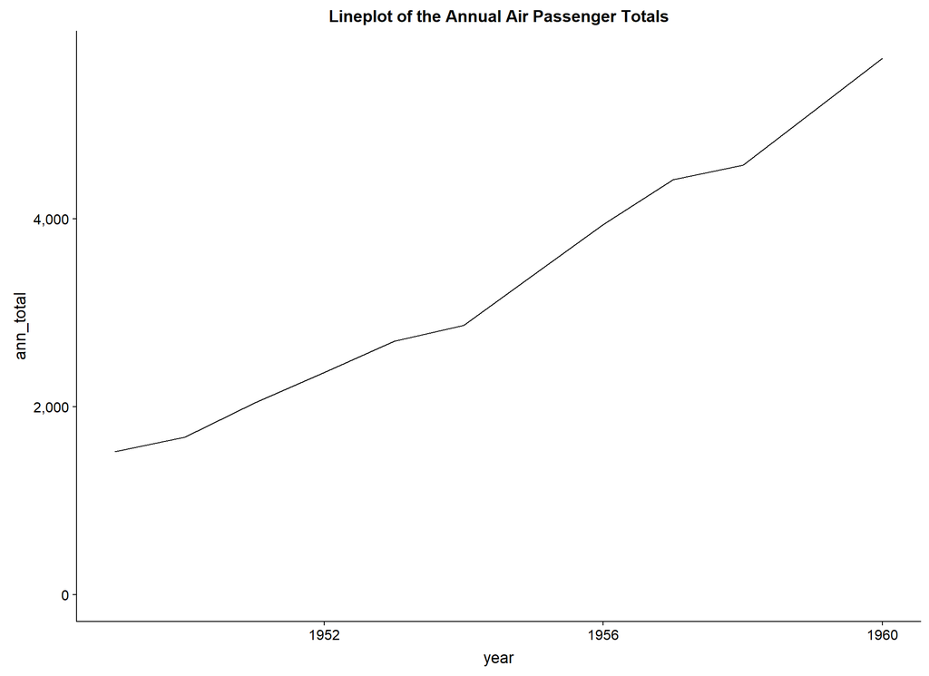

```r
ggplot(ap_yearly_tidyquant_tbl) +
    geom_line(aes(x = year, y = ann_total)) +
    expand_limits(y = 0) +
    scale_y_continuous(labels = comma) +
    ggtitle('Lineplot of the Annual Air Passenger Totals')
```

#### 2.1.1.1 Exercises

1. Aggregate the Maine unemployment data into yearly totals.
2. Create the relevant lineplots to check this data for trends and patterns.
3. Aggregate the CBE data into yearly totals.
4. Create plots of this data to check for trends.

### 2.1.2 Multiple Statistics

Should we need multiple statistics in our output, we implement this by writing a custom function that outputs the statistics we require.

```r
custom_stats_func <- function(x, na.rm = TRUE, ...) {
    c(
          sum    = sum(x, na.rm = na.rm)
         ,mean   = mean(x, na.rm = na.rm)
         ,sd     = sd(x, na.rm = na.rm)
         ,median = median(x, na.rm = na.rm)
         ,q25    = quantile(x, na.rm = na.rm, probs = 0.25, names = FALSE)
         ,q75    = quantile(x, na.rm = na.rm, probs = 0.75, names = FALSE)
    )
}


ap_yearly_tidyquant_custom_tbl <- airpassengers_tbl %>%
    tq_transmute(
        select     = value
       ,mutate_fun = apply.yearly
       ,FUN        = custom_stats_func
       ,na.rm      = TRUE
    ) %>%
    mutate(year = month %>% format('%Y') %>% as.numeric())


ap_yearly_tidyquant_custom_tbl %>% glimpse()
```

```
## Observations: 12
## Variables: 8
## $ month  <S3: yearmon> Dec 1949, Dec 1950, Dec 1951, Dec 1952, Dec 1953, De...
## $ sum    <dbl> 1520, 1676, 2042, 2364, 2700, 2867, 3408, 3939, 4421, 4572, ...
## $ mean   <dbl> 126.667, 139.667, 170.167, 197.000, 225.000, 238.917, 284.00...
## $ sd     <dbl> 13.7201, 19.0708, 18.4383, 22.9664, 28.4669, 34.9245, 42.140...
## $ median <dbl> 125.0, 137.5, 169.0, 192.0, 232.0, 231.5, 272.0, 315.0, 351....
## $ q25    <dbl> 118.00, 125.75, 159.00, 180.75, 199.75, 221.25, 260.75, 300....
## $ q75    <dbl> 135.25, 151.25, 179.50, 211.25, 238.50, 260.25, 312.75, 359....
## $ year   <dbl> 1949, 1950, 1951, 1952, 1953, 1954, 1955, 1956, 1957, 1958, ...
```

```r
ap_yearly_tidyquant_custom_tbl %>% print()
```

```
## # A tibble: 12 x 8
##    month           sum  mean    sd median   q25   q75  year
##    <S3: yearmon> <dbl> <dbl> <dbl>  <dbl> <dbl> <dbl> <dbl>
##  1 Dec 1949       1520  127.  13.7   125   118   135.  1949
##  2 Dec 1950       1676  140.  19.1   138.  126.  151.  1950
##  3 Dec 1951       2042  170.  18.4   169   159   180.  1951
##  4 Dec 1952       2364  197   23.0   192   181.  211.  1952
##  5 Dec 1953       2700  225   28.5   232   200.  238.  1953
##  6 Dec 1954       2867  239.  34.9   232.  221.  260.  1954
##  7 Dec 1955       3408  284   42.1   272   261.  313.  1955
##  8 Dec 1956       3939  328.  47.9   315   300.  360.  1956
##  9 Dec 1957       4421  368.  57.9   352.  331.  408.  1957
## 10 Dec 1958       4572  381   64.5   360.  339.  412.  1958
## 11 Dec 1959       5140  428.  69.8   406.  388.  465.  1959
## 12 Dec 1960       5714  476.  77.7   461   418.  515.  1960
```

#### 2.1.2.1 Exercises

1. Repeat the aggregation shown using the Maine unemployment data
2. Repeat the aggregation shown using the CBE data.
3. Create a custom function to calculate mean, sd, skew and kurtosis

## 2.2 Rolling Functions

Another common transformation of time-series is to apply a function over a fixed rolling window of data.

Note that rolling functions different conceptually from aggregates as they are not calculated over disjoint subsets of the data: the output is at the same time period as the original data.

Because of this difference we use a different function from `tidyquant` to execute this calculation: `tq_mutate()`:

### 2.2.1 Moving Averages

A common rolling function is the *moving average*: we calculate the average value of the time series over a fixed window of data.

```r
ap_rollmean_sixmonth_tbl <- airpassengers_tbl %>%
    tq_mutate(
        # tq_mutate args
        select     = value
       ,mutate_fun = rollapply
        # rollapply args
       ,width      = 6
       ,align      = "right"
       ,FUN        = mean
        # mean args
       ,na.rm      = TRUE
        # tq_mutate args
       ,col_rename = "mean_6m"
    )


ap_rollmean_sixmonth_tbl %>% glimpse()
```

```
## Observations: 144
## Variables: 3
## $ month   <S3: yearmon> Jan 1949, Feb 1949, Mar 1949, Apr 1949, May 1949, J...
## $ value   <dbl> 112, 118, 132, 129, 121, 135, 148, 148, 136, 119, 104, 118,...
## $ mean_6m <dbl> NA, NA, NA, NA, NA, 124.500, 130.500, 135.500, 136.167, 134...
```

```r
ap_rollmean_sixmonth_tbl %>% print()
```

```
## # A tibble: 144 x 3
##    month         value mean_6m
##    <S3: yearmon> <dbl>   <dbl>
##  1 Jan 1949        112     NA
##  2 Feb 1949        118     NA
##  3 Mar 1949        132     NA
##  4 Apr 1949        129     NA
##  5 May 1949        121     NA
##  6 Jun 1949        135    124.
##  7 Jul 1949        148    130.
##  8 Aug 1949        148    136.
##  9 Sep 1949        136    136.
## 10 Oct 1949        119    134.
## # ... with 134 more rows
```

We compare the two values by plotting the original time series against its moving average.

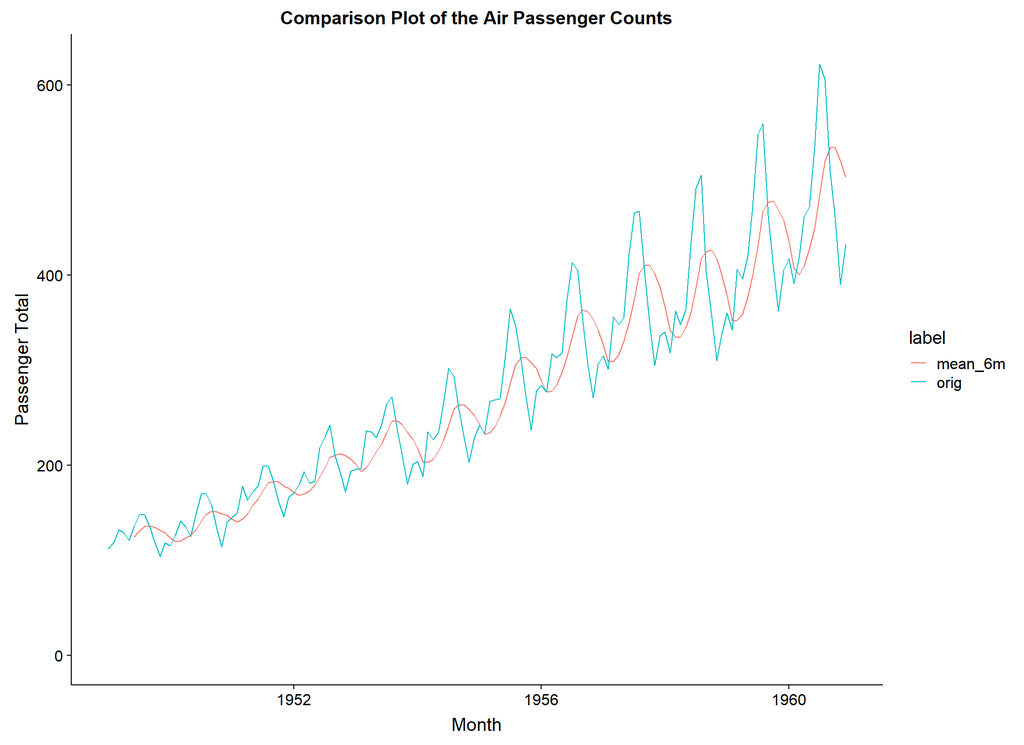

```r
plot_tbl <- ap_rollmean_sixmonth_tbl %>%
    rename(orig = value) %>%
    gather('label', 'value', -month)


ggplot(plot_tbl) +
    geom_line(aes(x = month, y = value, colour = label)) +
    expand_limits(y = 0) +
    scale_y_continuous(labels = comma) +
    xlab('Month') +
    ylab('Passenger Total') +
    ggtitle('Comparison Plot of the Air Passenger Counts')
```

Note that the moving-average series does not start at the same timestamp as the original dataset size is reduced by the windowing function.

We can add multiple moving averages to a time series by chaining a series of `tq_mutate()` calls together.

```r
ap_rollmean_multi_tbl <- airpassengers_tbl %>%
    tq_mutate(
        # tq_mutate args
        select     = value
       ,mutate_fun = rollapply
        # rollapply args
       ,width      = 6
       ,align      = "right"
       ,FUN        = mean
        # mean args
       ,na.rm      = TRUE
        # tq_mutate args
       ,col_rename = "mean_6m"
    ) %>%
    tq_mutate(
        # tq_mutate args
        select     = value
       ,mutate_fun = rollapply
        # rollapply args
       ,width      = 12
       ,align      = "right"
       ,FUN        = mean
        # mean args
       ,na.rm      = TRUE
        # tq_mutate args
       ,col_rename = "mean_12m"
    )


ap_rollmean_multi_tbl %>% glimpse()
```

```
## Observations: 144
## Variables: 4
## $ month    <S3: yearmon> Jan 1949, Feb 1949, Mar 1949, Apr 1949, May 1949, ...
## $ value    <dbl> 112, 118, 132, 129, 121, 135, 148, 148, 136, 119, 104, 118...
## $ mean_6m  <dbl> NA, NA, NA, NA, NA, 124.500, 130.500, 135.500, 136.167, 13...
## $ mean_12m <dbl> NA, NA, NA, NA, NA, NA, NA, NA, NA, NA, NA, 126.667, 126.9...
```

```r
ap_rollmean_multi_tbl %>% print()
```

```
## # A tibble: 144 x 4
##    month         value mean_6m mean_12m
##    <S3: yearmon> <dbl>   <dbl>    <dbl>
##  1 Jan 1949        112     NA        NA
##  2 Feb 1949        118     NA        NA
##  3 Mar 1949        132     NA        NA
##  4 Apr 1949        129     NA        NA
##  5 May 1949        121     NA        NA
##  6 Jun 1949        135    124.       NA
##  7 Jul 1949        148    130.       NA
##  8 Aug 1949        148    136.       NA
##  9 Sep 1949        136    136.       NA
## 10 Oct 1949        119    134.       NA
## # ... with 134 more rows
```

As before, we now create a lineplot of the three values to show the effect of the different window sizes.

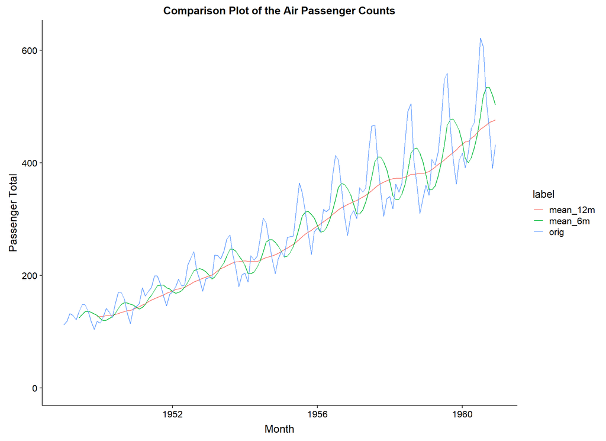

```r
plot_tbl <- ap_rollmean_multi_tbl %>%
    rename(orig = value) %>%
    gather('label', 'value', -month)


ggplot(plot_tbl) +
    geom_line(aes(x = month, y = value, colour = label)) +
    expand_limits(y = 0) +
    scale_y_continuous(labels = comma) +
    xlab('Month') +
    ylab('Passenger Total') +
    ggtitle('Comparison Plot of the Air Passenger Counts')
```

The twelve month time series is shorter than the six month series as it has a wider calculation window.

Any sort of other windowing functions can be applied, including the standard deviation, allowing us to include a range of possible values.

```r
ribbon_func <- function(x, na.rm = TRUE, ...) {
    mu    <- mean(x, na.rm = na.rm)
    sigma <- sd(x, na.rm = na.rm)

    lower <- mu - 2 * sigma
    upper <- mu + 2 * sigma

    return(c(mu = mu, l2sd = lower, u2sd = upper))
}


ap_roll_ribbon_tbl <- airpassengers_tbl %>%
    tq_mutate(
        # tq_mutate args
        select     = value
       ,mutate_fun = rollapply
        # rollapply args
       ,width      = 6
       ,align      = "right"
       ,by.column  = FALSE
       ,FUN        = ribbon_func
        # mean args
       ,na.rm      = TRUE
    )


ap_roll_ribbon_tbl %>% glimpse()
```

```
## Observations: 144
## Variables: 5
## $ month <S3: yearmon> Jan 1949, Feb 1949, Mar 1949, Apr 1949, May 1949, Jun...
## $ value <dbl> 112, 118, 132, 129, 121, 135, 148, 148, 136, 119, 104, 118, 1...
## $ mu    <dbl> NA, NA, NA, NA, NA, 124.500, 130.500, 135.500, 136.167, 134.5...
## $ l2sd  <dbl> NA, NA, NA, NA, NA, 106.6674, 109.0058, 114.0058, 114.9472, 1...
## $ u2sd  <dbl> NA, NA, NA, NA, NA, 142.333, 151.994, 156.994, 157.386, 159.6...
```

```r
ap_roll_ribbon_tbl %>% print()
```

```
## # A tibble: 144 x 5
##    month         value    mu  l2sd  u2sd
##    <S3: yearmon> <dbl> <dbl> <dbl> <dbl>
##  1 Jan 1949        112   NA    NA    NA
##  2 Feb 1949        118   NA    NA    NA
##  3 Mar 1949        132   NA    NA    NA
##  4 Apr 1949        129   NA    NA    NA
##  5 May 1949        121   NA    NA    NA
##  6 Jun 1949        135  124.  107.  142.
##  7 Jul 1949        148  130.  109.  152.
##  8 Aug 1949        148  136.  114.  157.
##  9 Sep 1949        136  136.  115.  157.
## 10 Oct 1949        119  134.  109.  160.
## # ... with 134 more rows
```

We now plot the original data against the moving average and the mean.

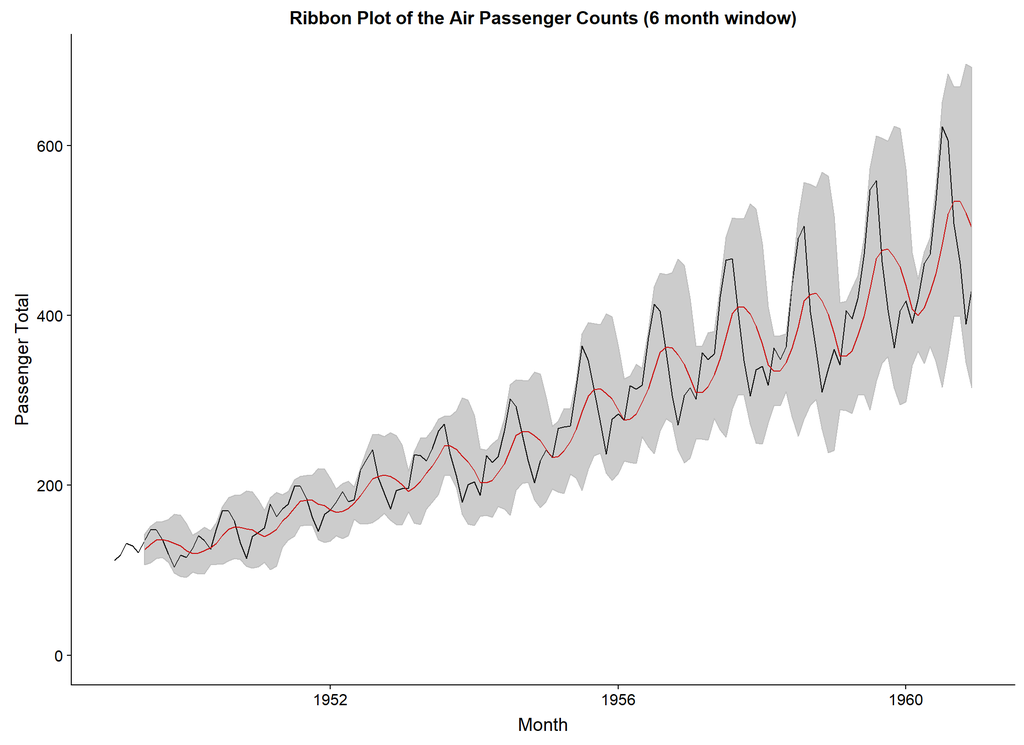

```r
ggplot(ap_roll_ribbon_tbl) +
    geom_line(aes(x = month, y = value)) +
    geom_line(aes(x = month, y = mu), colour = 'red') +
    geom_ribbon(aes(x = month, ymin = l2sd, ymax = u2sd)
               ,colour = 'grey', alpha = 0.25) +
    expand_limits(y = 0) +
    scale_y_continuous(labels = comma) +
    xlab('Month') +
    ylab('Passenger Total') +
    ggtitle('Ribbon Plot of the Air Passenger Counts (6 month window)')
```

We now repeat this process with using a twelve-month window for the data.

```r
ap_roll_12m_ribbon_tbl <- airpassengers_tbl %>%
    tq_mutate(
        # tq_mutate args
        select     = value
       ,mutate_fun = rollapply
        # rollapply args
       ,width      = 12
       ,align      = "right"
       ,by.column  = FALSE
       ,FUN        = ribbon_func
        # mean args
       ,na.rm      = TRUE
    )


ap_roll_12m_ribbon_tbl %>% glimpse()
```

```
## Observations: 144
## Variables: 5
## $ month <S3: yearmon> Jan 1949, Feb 1949, Mar 1949, Apr 1949, May 1949, Jun...
## $ value <dbl> 112, 118, 132, 129, 121, 135, 148, 148, 136, 119, 104, 118, 1...
## $ mu    <dbl> NA, NA, NA, NA, NA, NA, NA, NA, NA, NA, NA, 126.667, 126.917,...
## $ l2sd  <dbl> NA, NA, NA, NA, NA, NA, NA, NA, NA, NA, NA, 99.2264, 100.0100...
## $ u2sd  <dbl> NA, NA, NA, NA, NA, NA, NA, NA, NA, NA, NA, 154.107, 153.823,...
```

```r
ap_roll_12m_ribbon_tbl %>% print()
```

```
## # A tibble: 144 x 5
##    month         value    mu  l2sd  u2sd
##    <S3: yearmon> <dbl> <dbl> <dbl> <dbl>
##  1 Jan 1949        112    NA    NA    NA
##  2 Feb 1949        118    NA    NA    NA
##  3 Mar 1949        132    NA    NA    NA
##  4 Apr 1949        129    NA    NA    NA
##  5 May 1949        121    NA    NA    NA
##  6 Jun 1949        135    NA    NA    NA
##  7 Jul 1949        148    NA    NA    NA
##  8 Aug 1949        148    NA    NA    NA
##  9 Sep 1949        136    NA    NA    NA
## 10 Oct 1949        119    NA    NA    NA
## # ... with 134 more rows
```

Having constructed the data, we once again create a ribbon plot with these quantities.

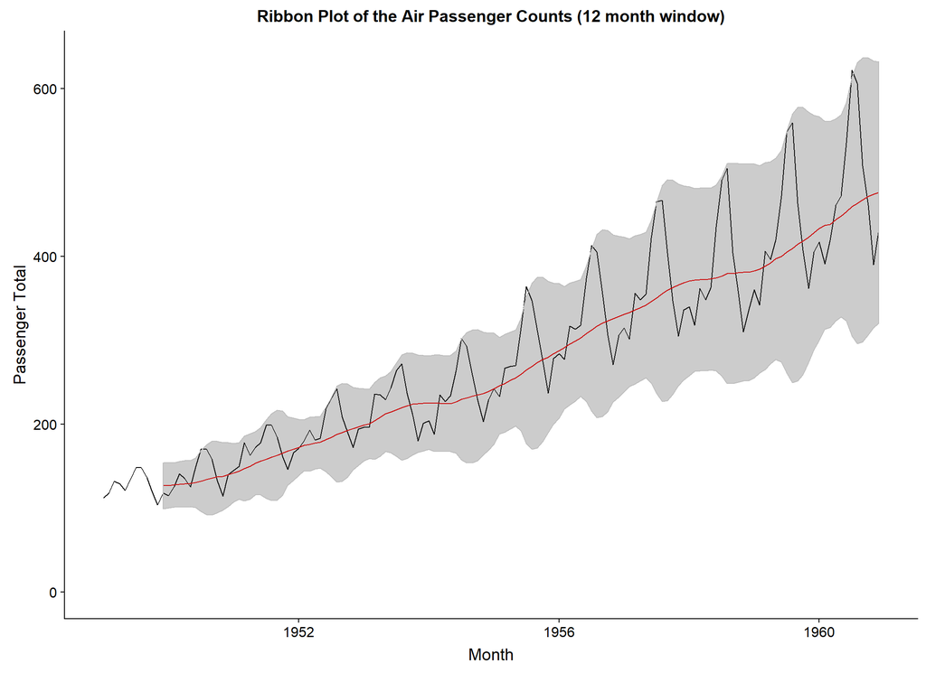

```r
ggplot(ap_roll_12m_ribbon_tbl) +
    geom_line(aes(x = month, y = value)) +
    geom_line(aes(x = month, y = mu), colour = 'red') +
    geom_ribbon(aes(x = month, ymin = l2sd, ymax = u2sd)
               ,colour = 'grey', alpha = 0.25) +
    expand_limits(y = 0) +
    scale_y_continuous(labels = comma) +
    xlab('Month') +
    ylab('Passenger Total') +
    ggtitle('Ribbon Plot of the Air Passenger Counts (12 month window)')
```

#### 2.2.1.1 Exercises

1. Construct a 3 month moving average for the passenger data and compare it to the 6 and 12 month values.
2. Calculate the 6 month and 12 month rolling average values for the Maine unemployment data.
3. Construct the ribbon plot for the Maine unemployment data.
4. Construct moving average data for the CBE dataset. This process may be made easier by reshaping the data.

### 2.2.2 Differences

Another common transformation of the data is to take the ‘first differences’ of the values, i.e. we convert the time series of values into one of differences. We discuss the reasons for this later on – for now we focus on the mechanics of creating first differences.

```r
ap_firstdiff_tbl <- airpassengers_tbl %>%
    mutate(diff = value - lag(value, n = 1))


ap_firstdiff_tbl %>% glimpse()
```

```
## Observations: 144
## Variables: 3
## $ month <S3: yearmon> Jan 1949, Feb 1949, Mar 1949, Apr 1949, May 1949, Jun...
## $ value <dbl> 112, 118, 132, 129, 121, 135, 148, 148, 136, 119, 104, 118, 1...
## $ diff  <dbl> NA, 6, 14, -3, -8, 14, 13, 0, -12, -17, -15, 14, -3, 11, 15, ...
```

```r
ap_firstdiff_tbl %>% print()
```

```
## # A tibble: 144 x 3
##    month         value  diff
##    <S3: yearmon> <dbl> <dbl>
##  1 Jan 1949        112    NA
##  2 Feb 1949        118     6
##  3 Mar 1949        132    14
##  4 Apr 1949        129    -3
##  5 May 1949        121    -8
##  6 Jun 1949        135    14
##  7 Jul 1949        148    13
##  8 Aug 1949        148     0
##  9 Sep 1949        136   -12
## 10 Oct 1949        119   -17
## # ... with 134 more rows
```

Having calculated the differences, we now produce a lineplot of those values.

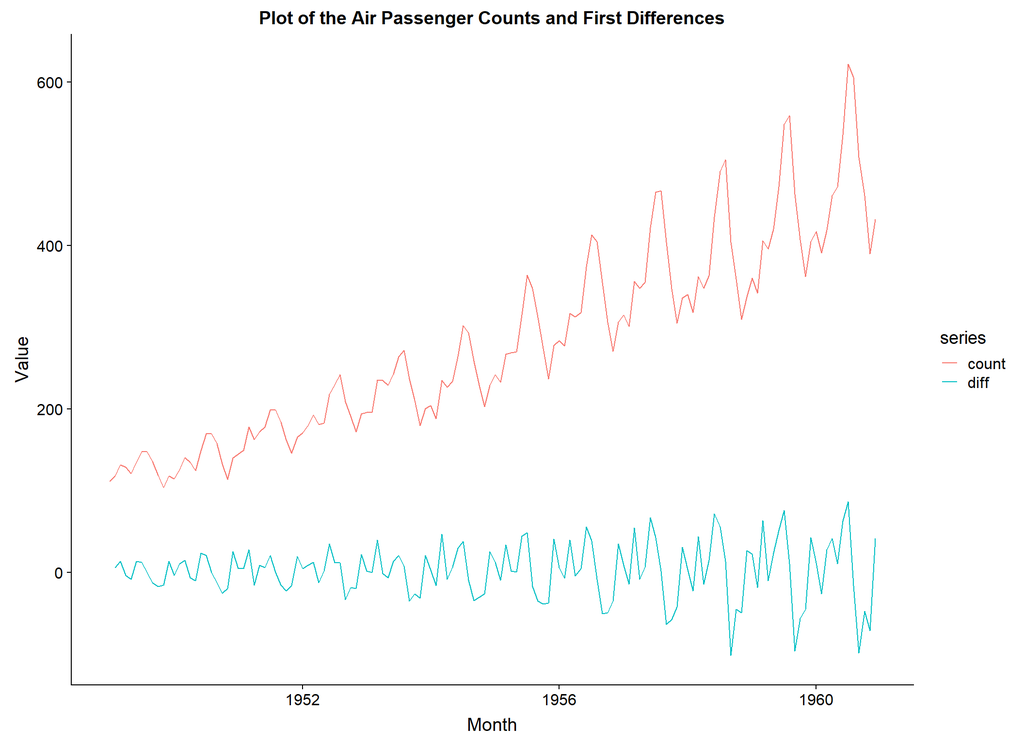

```r
plot_tbl <- ap_firstdiff_tbl %>%
    rename(count = value) %>%
    gather('series', 'value', -month)


ggplot(plot_tbl) +
    geom_line(aes(x = month, y = value, colour = series)) +
    scale_y_continuous(labels = comma) +
    expand_limits(y = 0) +
    xlab('Month') +
    ylab('Value') +
    ggtitle('Plot of the Air Passenger Counts and First Differences')
```

As we see with this plot, the first differences of the passenger data does not contain a trend.

#### 2.2.2.1 Exercises

1. Calculate the first differences for the Maine unemployment data.
2. Create a lineplot of this data to check for its value.
3. Calculate the first differences for the CBE data.
4. Create lineplots for the CBE differences.
5. Using the `lag()` function with the Air Passenger data, calculate the percentage changes data instead of the arithmetic changes.
6. Construct the lineplot for the percentage change values.

# 3 Exploratory Data Analysis of Time Series

The first step in all exploratory analysis is simple visualisation: simple lines plots such as those we have seen are our starting point. The human brain is excellent at pattern recognition, so a simple plot often guides our analysis more effectively than a suite of numerical diagnostics.

Rather than discuss different techniques, we will explore our sample data as a way to illustrate some ways of initially exploring the datasets.

## 3.1 Air Passenger

We start with the air passenger data, and remind ourselves of the basic structure of the data.

```r
airpassengers_tbl %>% glimpse()
```

```
## Observations: 144
## Variables: 2
## $ month <S3: yearmon> Jan 1949, Feb 1949, Mar 1949, Apr 1949, May 1949, Jun...
## $ value <dbl> 112, 118, 132, 129, 121, 135, 148, 148, 136, 119, 104, 118, 1...
```

```r
airpassengers_tbl %>% print()
```

```
## # A tibble: 144 x 2
##    month         value
##    <S3: yearmon> <dbl>
##  1 Jan 1949        112
##  2 Feb 1949        118
##  3 Mar 1949        132
##  4 Apr 1949        129
##  5 May 1949        121
##  6 Jun 1949        135
##  7 Jul 1949        148
##  8 Aug 1949        148
##  9 Sep 1949        136
## 10 Oct 1949        119
## # ... with 134 more rows
```

### 3.1.1 Raw Data

We remind ourselves of the lineplot of the raw data.

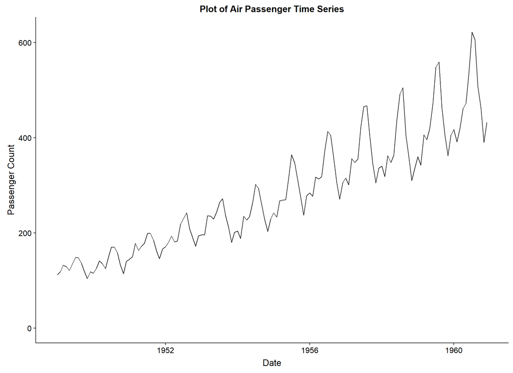

```r
ggplot(airpassengers_tbl) +
    geom_line(aes(x = month, y = value)) +
    xlab('Date') +
    ylab('Passenger Count') +
    expand_limits(y = 0) +
    ggtitle('Plot of Air Passenger Time Series')
```

This plot suggests a strong seasonal effect as well as a trend so this is the first thing to investigate.

It may help if we can add points to the plot to indicate the months, so we add points for the month of June to help us identify years.

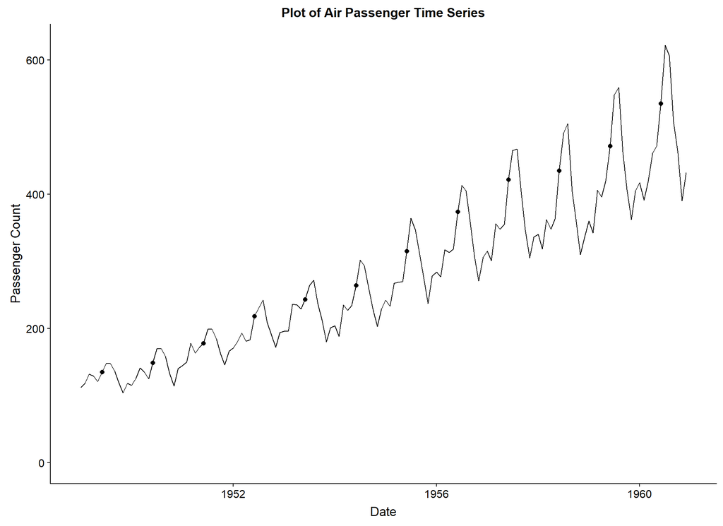

```r
ap_jun_tbl <- airpassengers_tbl %>% filter(format(month, '%m') == '06')

ggplot(airpassengers_tbl) +
    geom_line(aes(x = month, y = value)) +
    geom_point(aes(x = month, y = value), data = ap_jun_tbl, size = 2) +
    xlab('Date') +
    ylab('Passenger Count') +
    expand_limits(y = 0) +
    ggtitle('Plot of Air Passenger Time Series')
```

To look into trends, we have a number of options: we could look at yearly sums or averages, or we could look at moving averages.

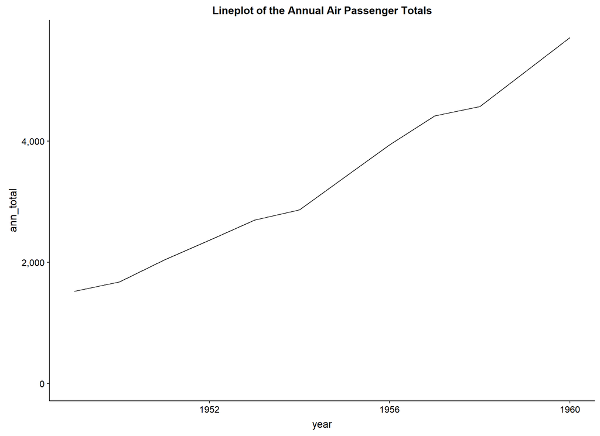

```r
ggplot(ap_yearly_tidyquant_tbl) +
    geom_line(aes(x = year, y = ann_total)) +
    expand_limits(y = 0) +
    scale_y_continuous(labels = comma) +
    ggtitle('Lineplot of the Annual Air Passenger Totals')
```

One way to investigate the seasonality in the dataset is to construct a boxplot of the passenger counts, grouping by month.

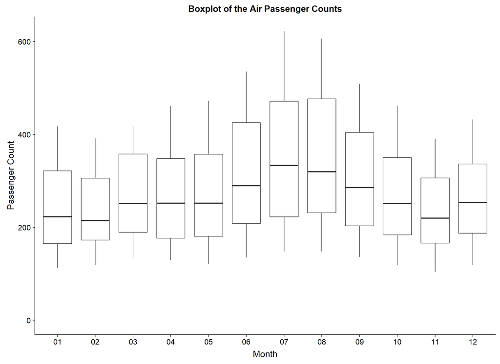

```r
plot_tbl <- airpassengers_tbl %>%
    mutate(cal_month = format(month, '%m'))

ggplot(plot_tbl) +
    geom_boxplot(aes(x = cal_month, y = value)) +
    scale_y_continuous(labels = comma) +
    expand_limits(y = 0) +
    xlab('Month') +
    ylab('Passenger Count') +
    ggtitle('Boxplot of the Air Passenger Counts')
```

We can see some aspects of the data seasonality in this boxplot, but the multiplicative nature of the plots means the seasonal trends is obscured a little.

### 3.1.2 First Differences

We also produce a similar boxplot, but this time looking at the first differences.

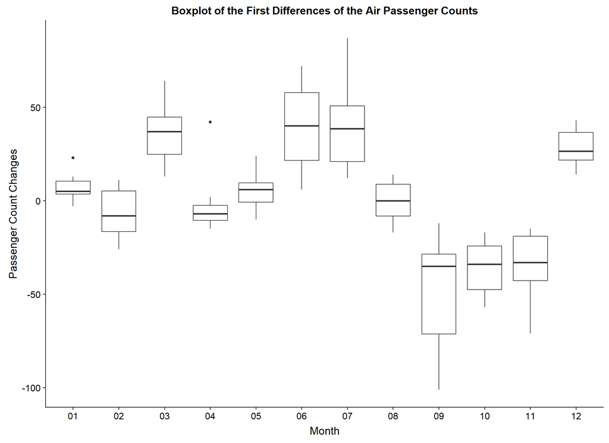

```r
plot_tbl <- ap_firstdiff_tbl %>%
    mutate(cal_month = format(month, '%m'))

ggplot(plot_tbl) +
    geom_boxplot(aes(x = cal_month, y = diff)) +
    expand_limits(y = 0) +
    scale_y_continuous(labels = comma) +
    xlab('Month') +
    ylab('Passenger Count Changes') +
    ggtitle('Boxplot of the First Differences of the Air Passenger Counts')
```

The seasonality in the data comes through much stronger with this plot. We see much bigger monthly effects.

### 3.1.3 Percentage Changes

To look into multiplicative effects we check the percentage changes from month to month.

```r
ap_perc_change_tbl <- airpassengers_tbl %>%
    mutate(cal_month   = format(month, '%m')
          ,perc_change = value / lag(value, n = 1) - 1)


ap_perc_change_tbl %>% glimpse()
```

```
## Observations: 144
## Variables: 4
## $ month       <S3: yearmon> Jan 1949, Feb 1949, Mar 1949, Apr 1949, May 194...
## $ value       <dbl> 112, 118, 132, 129, 121, 135, 148, 148, 136, 119, 104, ...
## $ cal_month   <chr> "01", "02", "03", "04", "05", "06", "07", "08", "09", "...
## $ perc_change <dbl> NA, 0.0535714, 0.1186441, -0.0227273, -0.0620155, 0.115...
```

```r
ap_perc_change_tbl %>% print()
```

```
## # A tibble: 144 x 4
##    month         value cal_month perc_change
##    <S3: yearmon> <dbl> <chr>           <dbl>
##  1 Jan 1949        112 01            NA
##  2 Feb 1949        118 02             0.0536
##  3 Mar 1949        132 03             0.119
##  4 Apr 1949        129 04            -0.0227
##  5 May 1949        121 05            -0.0620
##  6 Jun 1949        135 06             0.116
##  7 Jul 1949        148 07             0.0963
##  8 Aug 1949        148 08             0
##  9 Sep 1949        136 09            -0.0811
## 10 Oct 1949        119 10            -0.125
## # ... with 134 more rows
```

Having looked at the data and the column, we now look at some simple lineplots as before.

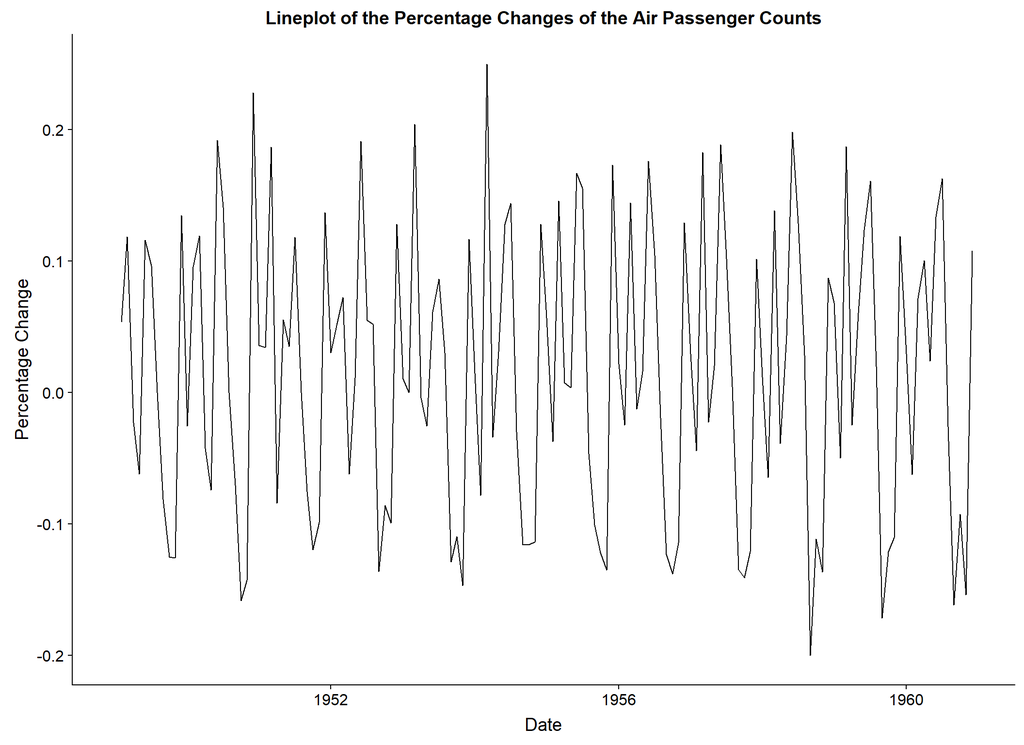

```r
ggplot(ap_perc_change_tbl) +
    geom_line(aes(x = month, y = perc_change)) +
    expand_limits(y = 0) +
    xlab('Date') +
    ylab('Percentage Change') +
    ggtitle('Lineplot of the Percentage Changes of the Air Passenger Counts')
```

Much like the arithmetic differences, the percentage changes are centred around zero, so now we can look at a boxplot of them.

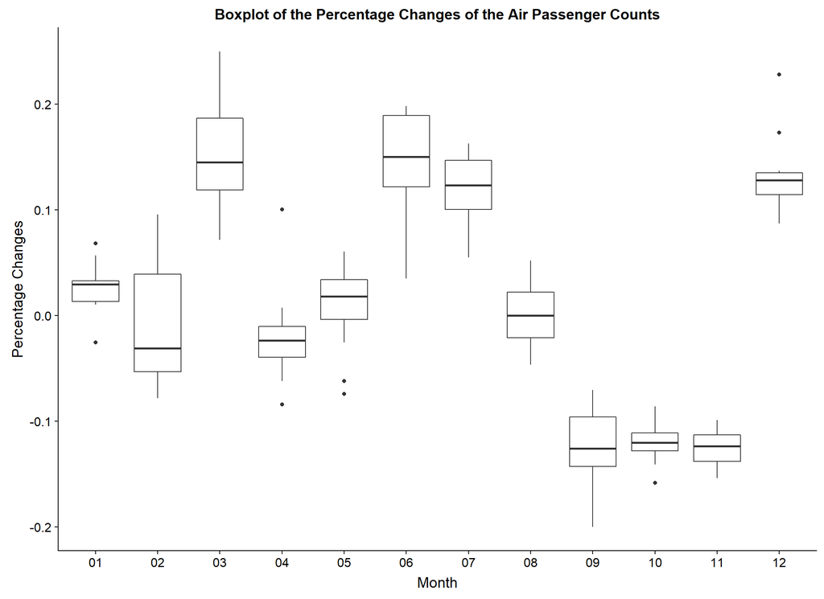

```r
ggplot(ap_perc_change_tbl) +
    geom_boxplot(aes(x = cal_month, y = perc_change)) +
    xlab('Month') +
    ylab('Percentage Changes') +
    ggtitle('Boxplot of the Percentage Changes of the Air Passenger Counts')
```

## 3.2 Maine Unemployment

We now explore the Maine unemployment data.

As before, we look at the raw data, the first differences and the percentage changes.

```r
maine_explore_tbl <- maine_tbl %>%
    mutate(cal_month   = format(month, '%m')
          ,diff        = value - lag(value, n = 1)
          ,perc_change = value / lag(value, n = 1) - 1
           )


maine_explore_tbl %>% glimpse()
```

```
## Observations: 128
## Variables: 5
## $ month       <S3: yearmon> Jan 1996, Feb 1996, Mar 1996, Apr 1996, May 199...
## $ value       <dbl> 6.7, 6.7, 6.4, 5.9, 5.2, 4.8, 4.8, 4.0, 4.2, 4.4, 5.0, ...
## $ cal_month   <chr> "01", "02", "03", "04", "05", "06", "07", "08", "09", "...
## $ diff        <dbl> NA, 0.0, -0.3, -0.5, -0.7, -0.4, 0.0, -0.8, 0.2, 0.2, 0...
## $ perc_change <dbl> NA, 0.0000000, -0.0447761, -0.0781250, -0.1186441, -0.0...
```

```r
maine_explore_tbl %>% print()
```

```
## # A tibble: 128 x 5
##    month         value cal_month    diff perc_change
##    <S3: yearmon> <dbl> <chr>       <dbl>       <dbl>
##  1 Jan 1996        6.7 01         NA         NA
##  2 Feb 1996        6.7 02          0          0
##  3 Mar 1996        6.4 03         -0.300     -0.0448
##  4 Apr 1996        5.9 04         -0.5       -0.0781
##  5 May 1996        5.2 05         -0.7       -0.119
##  6 Jun 1996        4.8 06         -0.4       -0.0769
##  7 Jul 1996        4.8 07          0          0
##  8 Aug 1996        4   08         -0.800     -0.167
##  9 Sep 1996        4.2 09          0.2        0.05
## 10 Oct 1996        4.4 10          0.2        0.0476
## # ... with 118 more rows
```

### 3.2.1 Raw Data

We start by the standard lineplot of the values.

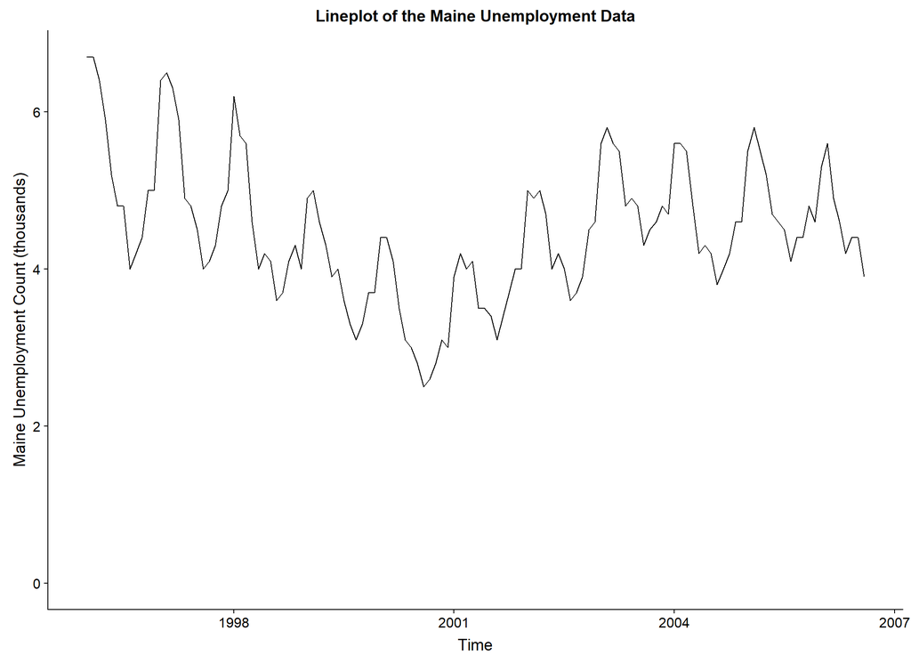

```r
ggplot(maine_explore_tbl) +
    geom_line(aes(x = month, y = value)) +
    expand_limits(y = 0) +
    scale_y_continuous(labels = comma) +
    xlab('Time') +
    ylab('Maine Unemployment Count (thousands)') +
    ggtitle('Lineplot of the Maine Unemployment Data')
```

We do not see a trend in this data but the data does seem to have strong seasonal patterns.

To investigate the seasonality we construct the monthly boxplots from the raw data. Employment is often seasonal in nature - for example, retail is very busy towards Christmas each year. As such, we expect to see a large seasonal component in this data.

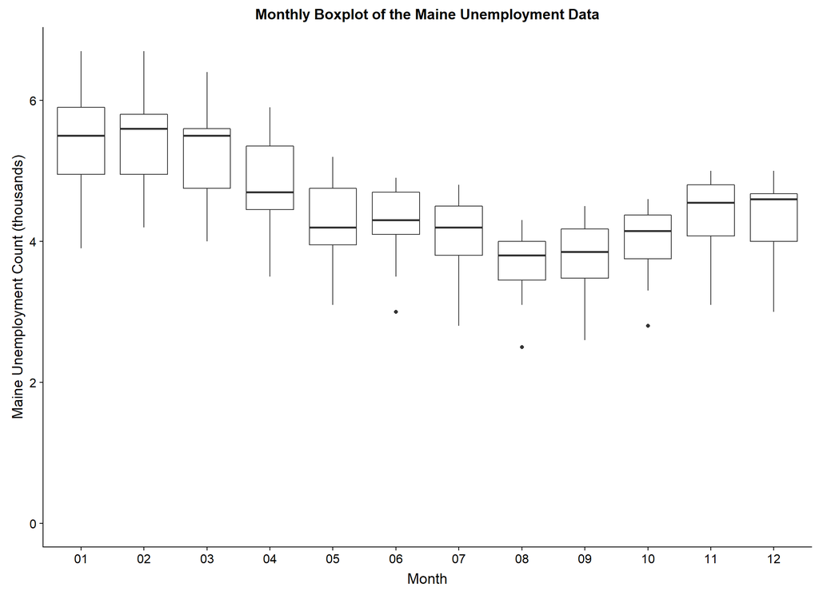

```r
ggplot(maine_explore_tbl) +
    geom_boxplot(aes(x = cal_month, y = value)) +
    expand_limits(y = 0) +
    scale_y_continuous(labels = comma) +
    xlab('Month') +
    ylab('Maine Unemployment Count (thousands)') +
    ggtitle('Monthly Boxplot of the Maine Unemployment Data')
```

We see definite changes over the months, though the effect does not seem as pronounced here as it was for the airline passenger counts.

### 3.2.2 First Differences

We now look at first differences for the unemployment data, and start with the line plot.

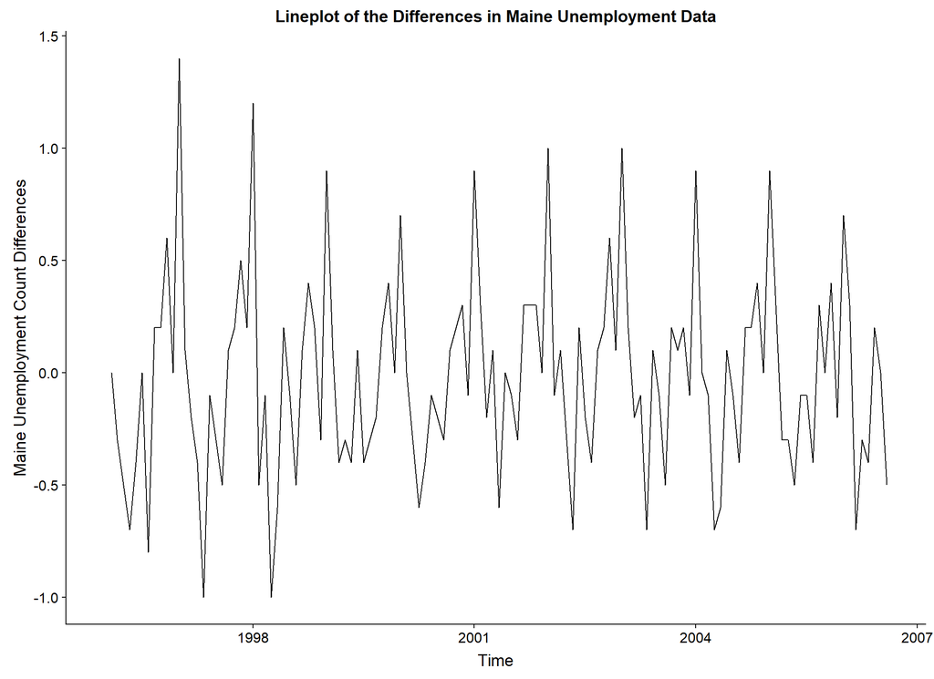

```r
ggplot(maine_explore_tbl) +
    geom_line(aes(x = month, y = diff)) +
    expand_limits(y = 0) +
    xlab('Time') +
    ylab('Maine Unemployment Count Differences') +
    ggtitle('Lineplot of the Differences in Maine Unemployment Data')
```

The original data does not exhibit a strong trend, and the first differences are similar.

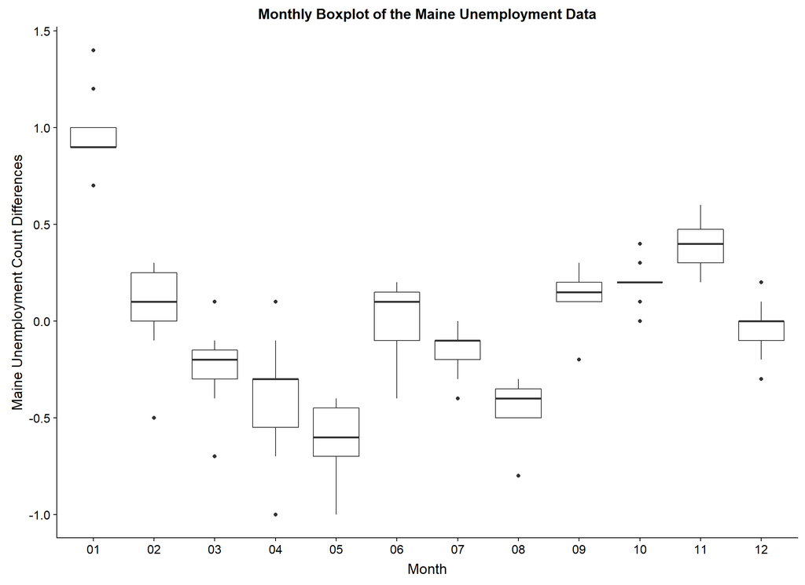

```r
ggplot(maine_explore_tbl) +
    geom_boxplot(aes(x = cal_month, y = diff)) +
    expand_limits(y = 0) +
    xlab('Month') +
    ylab('Maine Unemployment Count Differences') +
    ggtitle('Monthly Boxplot of the Maine Unemployment Data')
```

We see strong seasonal differences in the monthly data.